# Reviewing summary statistics from the COVID19-HGI

[Sander W. van der Laan, PhD](https://swvanderlaan.github.io) | @swvanderlaan | s.w.vanderlaan@gmail.com

2020-05-17

# Setup

We will clean the environment, setup the locations, define colors, and create a datestamp.

*Clean the environment.*

*Set locations and working directories…*

```
Create a new analysis directory...
[1] FALSE
[1] FALSE
[1] FALSE
[1] FALSE
[1] FALSE
[1] "/Users/swvanderlaan/PLINK/analyses/covid19_hgi/covid19_hg"
 [1] "20200514.COVID19.PRELIMINARYRELEASE1.RData" "20200516.COVID19.PRELIMINARYRELEASE1.RData" "covid19_hg.nb.html"
 [4] "covid19_hg.Rmd"                             "covid19_hg.Rproj"                           "COVID19.PRELIMINARYRELEASE1"
 [7] "COVID19.PRELIMINARYRELEASE2"                "LICENSE"                                    "README.md"
[10] "SCRIPTS"
```

*… a package-installation function …*

```r
install.packages.auto <- function(x) {
  x <- as.character(substitute(x))
  if (isTRUE(x %in% .packages(all.available = TRUE))) {
    eval(parse(text = sprintf("require(\"%s\")", x)))
  } else {
    # Update installed packages - this may mean a full upgrade of R, which in turn
    # may not be warrented.
    #update.packages(ask = FALSE)
    eval(parse(text = sprintf("install.packages(\"%s\", dependencies = TRUE, repos = \"http://cran-mirror.cs.uu.nl/\")", x)))
  }
  if (isTRUE(x %in% .packages(all.available = TRUE))) {
    eval(parse(text = sprintf("require(\"%s\")", x)))
  } else {
    source("http://bioconductor.org/biocLite.R")
    # Update installed packages - this may mean a full upgrade of R, which in turn
    # may not be warrented.
    #biocLite(character(), ask = FALSE)
    eval(parse(text = sprintf("biocLite(\"%s\")", x)))
    eval(parse(text = sprintf("require(\"%s\")", x)))
  }
}
```

*… and load those packages.*

```r
install.packages.auto("readr")
install.packages.auto("optparse")
install.packages.auto("tools")
install.packages.auto("dplyr")
install.packages.auto("tidyr")
install.packages.auto("naniar")
# To get 'data.table' with 'fwrite' to be able to directly write gzipped-files
# Ref: https://stackoverflow.com/questions/42788401/is-possible-to-use-fwrite-from-data-table-with-gzfile
# install.packages("data.table", repos = "https://Rdatatable.gitlab.io/data.table")
library(data.table)
install.packages.auto("tidyverse")
```

```
x data.table::between() masks dplyr::between()
x data.table::first()   masks dplyr::first()
x data.table::last()    masks dplyr::last()
```

```r
install.packages.auto("knitr")
install.packages.auto("DT")
install.packages.auto("eeptools")
```

```
Welcome to eeptools for R version 1.2.0!
Developed by Jared E. Knowles 2012-2018
for the Wisconsin Department of Public Instruction
Distributed without warranty.
```

```r
install.packages.auto("haven")
install.packages.auto("tableone")
install.packages.auto("ggpubr")
install.packages.auto("BlandAltmanLeh")
install.packages.auto("ggplot2")

install.packages.auto("CMplot")
```

```
Much appreciate for using CMplot.
Full description, Bug report, Suggestion and the latest codes:
https://github.com/YinLiLin/R-CMplot
```

```r
# For regional association plots
devtools::install_github("jrs95/gassocplot")
```

*We will create a datestamp and define the Utrecht Science Park Colour Scheme*.

```r
Today = format(as.Date(as.POSIXlt(Sys.time())), "%Y%m%d")
Today.Report = format(as.Date(as.POSIXlt(Sys.time())), "%A, %B %d, %Y")

### UtrechtScienceParkColoursScheme
###
### WebsitetoconvertHEXtoRGB:http://hex.colorrrs.com.
### Forsomefunctionsyoushoulddividethesenumbersby255.
###
### No. Color                 HEX   (RGB)                                     CHR         MAF/INFO
###---------------------------------------------------------------------------------------
### 1     yellow                #FBB820 (251,184,32)                      =>    1       or 1.0>INFO
### 2     gold                #F59D10 (245,157,16)                    =>    2
### 3     salmon                #E55738 (229,87,56)                   =>    3       or 0.05<MAF<0.2 or 0.4<INFO<0.6
### 4     darkpink          #DB003F ((219,0,63)                   =>    4
### 5     lightpink         #E35493 (227,84,147)                      =>    5       or 0.8<INFO<1.0
### 6     pink                #D5267B (213,38,123)                    =>    6
### 7     hardpink          #CC0071 (204,0,113)                   =>    7
### 8     lightpurple       #A8448A (168,68,138)                      =>    8
### 9     purple                #9A3480 (154,52,128)                      =>    9
### 10  lavendel            #8D5B9A (141,91,154)                      =>    10
### 11  bluepurple        #705296 (112,82,150)                    =>    11
### 12  purpleblue        #686AA9 (104,106,169)               =>    12
### 13  lightpurpleblue #6173AD (97,115,173/101,120,180)    =>  13
### 14  seablue             #4C81BF (76,129,191)                      =>    14
### 15  skyblue             #2F8BC9 (47,139,201)                      =>    15
### 16  azurblue            #1290D9 (18,144,217)                      =>    16      or 0.01<MAF<0.05 or 0.2<INFO<0.4
### 17  lightazurblue     #1396D8 (19,150,216)                    =>    17
### 18  greenblue           #15A6C1 (21,166,193)                      =>    18
### 19  seaweedgreen      #5EB17F (94,177,127)                    =>    19
### 20  yellowgreen       #86B833 (134,184,51)                    =>    20
### 21  lightmossgreen  #C5D220 (197,210,32)                      =>    21
### 22  mossgreen           #9FC228 (159,194,40)                      =>    22      or MAF>0.20 or 0.6<INFO<0.8
### 23  lightgreen      #78B113 (120,177,19)                      =>    23/X
### 24  green                 #49A01D (73,160,29)                     =>    24/Y
### 25  grey                  #595A5C (89,90,92)                        =>  25/XY   or MAF<0.01 or 0.0<INFO<0.2
### 26  lightgrey           #A2A3A4 (162,163,164)                 =>    26/MT
###
### ADDITIONAL COLORS
### 27  midgrey         #D7D8D7
### 28  verylightgrey   #ECECEC"
### 29  white           #FFFFFF
### 30  black           #000000
###----------------------------------------------------------------------------------------------

uithof_color = c("#FBB820","#F59D10","#E55738","#DB003F","#E35493","#D5267B",
                 "#CC0071","#A8448A","#9A3480","#8D5B9A","#705296","#686AA9",
                 "#6173AD","#4C81BF","#2F8BC9","#1290D9","#1396D8","#15A6C1",
                 "#5EB17F","#86B833","#C5D220","#9FC228","#78B113","#49A01D",
                 "#595A5C","#A2A3A4", "#D7D8D7", "#ECECEC", "#FFFFFF", "#000000")

uithof_color_legend = c("#FBB820", "#F59D10", "#E55738", "#DB003F", "#E35493",
                        "#D5267B", "#CC0071", "#A8448A", "#9A3480", "#8D5B9A",
                        "#705296", "#686AA9", "#6173AD", "#4C81BF", "#2F8BC9",
                        "#1290D9", "#1396D8", "#15A6C1", "#5EB17F", "#86B833",
                        "#C5D220", "#9FC228", "#78B113", "#49A01D", "#595A5C",
                        "#A2A3A4", "#D7D8D7", "#ECECEC", "#FFFFFF", "#000000")
### ----------------------------------------------------------------------------
```

# COVID19 Host Genetic Initiative

Some friends and colleagues asked about the preliminary results from the genetics studies on COVID19. One large-scale effort is the [COVID-19 Host Genetics Initiative (COVID19-HGI)](https://www.covid19hg.org)[^1] which aims to bring together the human genetics community to generate, share and analyze data to learn the genetic determinants of COVID-19 susceptibility, severity and outcomes. Ultimately, these discoveries could help to generate hypotheses for drug repurposing, identify individuals at unusually high or low risk, and contribute to global knowledge of the biology of SARS-CoV-2 infection and disease.

In this repository I just wanted to share a quick look at the (preliminary) results from the rounds of meta-analysis of genome-wide association studies (GWAS) included.

> First Release Notes: An important caveat here is that these data really are just that: preliminary. The phenotype definition used here does not accurately capture disease susceptibility and severity. Read more about this [here](https://www.covid19hg.org/blog/2020-04-30-first-round-of-meta-analysis-results/).

> Second Release Notes: Meta-analysis was done with inverse variance weighting. Positions are on GRCh37. An allele frequency (AF) filter of 0.0001 and an imputation quality (INFO) filter of 0.6 was applied to each study prior to meta-analysis. Read more [here](https://www.covid19hg.org/results/).

## Data description

Data column descriptions:

- #CHR: chromosome,
- POS: chromosome position in build 37,
- REF: non-effect allele,
- ALT: effect allele (beta is for this allele),
- SNP: #CHR:POS:REF:ALT,
- {STUDY}_AF_Allele2: allele frequency in {STUDY},
- all_meta_N: number of studies that had the variant after AF and INFO filtering and as such were used for the meta,
- all_inv_var_meta_beta: effect size on log(OR) scale,
- all_inv_var_meta_sebeta: standard error of effect size,
- all_inv_var_meta_p: p-value,
- all_inv_var_het_p: p-value from Cochran’s Q heterogeneity test.

## Analyses

There are several analyses carried out for COVID-19 susceptibility, severity and outcomes.

- ANA2, Hospitalized vs. non-hospitalized
- ANA5, susceptibility (affected vs. population)
- ANA7, COVID-19 predicted by flu-like symptoms

### Analysis 2: 20200508-results-ANA2_inv_var_meta

*Phenotype*: ANA2, Hospitalized vs. non-hospitalized. *Population*: All.

*Total cases*: 716. *Total controls*: 616.

*Contributing studies (n_cases, n_controls)*:

- FinnGen_FIN (30, 179),
- GNH_SAS (34, 13),
- LifelinesGsa_EUR (6, 183),
- PHBB_EUR (17, 57),
- UKBB_EUR (629, 184).

Downloads:

- COVID19_HGI_ANA2_20200513.txt.gz
- COVID19_HGI_ANA2_20200513.txt.gz.tbi

### Analysis 5: 20200508-results-ANA5_ALL_inv_var_meta

*Phenotype*: ANA5, susceptibility (affected vs. population). *Population*: All.

*Total cases*: 1,678. *Total controls*: 674,635.

*Contributing studies (n_cases, n_controls)*:

- BioMe_RGN_EUR (20, 10169),
- FinnGen_FIN (209, 203431),
- GNH_SAS (64, 27351),
- LifelinesCyto_EUR (62, 5750),
- LifelinesGsa_EUR (189, 15975),
- NTR_CEU (163, 3160),
- PHBB_AFR (34, 2169),
- PHBB_EUR (74, 28950),
- UKBB_AFR (51, 6585),
- UKBB_EUR (812, 371095).

Downloads:

- COVID19_HGI_ANA5_20200513.txt.gz
- COVID19_HGI_ANA5_20200513.txt.gz.tbi

### Analysis 7: 20200508-results-ANA7_inv_var_meta

*Phenotype*: ANA7, COVID-19 predicted by flu-like symptoms. *Population*: European.

*Total cases*: 1,294. *Total controls*: 26,969.

*Contributing studies (n_cases, n_controls)*:

- LifelinesGsa_EUR (443, 15406),
- LifelinesCyto_EUR (194, 5451),
- Helix_EUR (657, 6112).

Downloads:

- COVID19_HGI_ANA7_20200513.txt.gz
- COVID19_HGI_ANA7_20200513.txt.gz.tbi

# Loading data

We have downloaded the data from the [site](https://www.covid19hg.org/) and stored this locally.

```r
cat("Getting results ...\n")
```

```
Getting results ...
```

```r
cat("\n* analysis 2 ...\n")
```

```
* analysis 2 ...
```

```r
prelim.gwas.raw <- fread(paste0(RAWDATA_loc,"/COVID19_HGI_ANA2_20200513.txt.gz"),
                         header = TRUE,
                         verbose = FALSE,
                         showProgress = TRUE)
```

```
|--------------------------------------------------|
|==================================================|
```

```r
cat("\n* analysis 5 ...\n")
```

```
* analysis 5 ...
```

```r
prelim.gwas.raw5 <- fread(paste0(RAWDATA_loc,"/COVID19_HGI_ANA5_20200513.txt.gz"),
                         header = TRUE,
                         verbose = FALSE,
                         showProgress = TRUE)
```

```
|--------------------------------------------------|
|==================================================|
```

```r
cat("\n* analysis 7 ...\n")
```

```
* analysis 7 ...
```

```r
prelim.gwas.raw7 <- fread(paste0(RAWDATA_loc,"/COVID19_HGI_ANA7_20200513.txt.gz"),
                         header = TRUE,
                         verbose = FALSE,
                         showProgress = TRUE)
```

```
|--------------------------------------------------|
|==================================================|
```

Here we take a random sample of the data for debugging this script if `DEBUGGING_FLAG` equals `YES`.

```r
# for debug
# random sampling

if (DEBUGGING_FLAG == "YES") {
  cat("We are in debugging mode.")

  sample.size = 500000

  prelim.gwas.raw <- prelim.gwas.raw %>%
    sample_n(., sample.size)

  prelim.gwas.raw5 <- prelim.gwas.raw5 %>%
    sample_n(., sample.size)

  prelim.gwas.raw7 <- prelim.gwas.raw7 %>%
    sample_n(., sample.size)


} else if (DEBUGGING_FLAG == "NO") {
  cat("Real-mode: using all data.")

  } else {
    cat("This message must be attributable to human error. Please check the debugging flag.")

    }
```

```
We are in debugging mode.
```

Summarizing the data, and get a `head` of each dataset.

```r
cat("\n* analysis 2 ...\n")
```

```
* analysis 2 ...
```

```r
str(prelim.gwas.raw)
```

```
'data.frame':   500000 obs. of  15 variables:
 $ #CHR                       : int  17 12 7 6 15 3 3 5 7 14 ...
 $ POS                        : int  28470493 108980536 105651227 51803341 93746514 148276754 178969361 127533085 55310341 88598095 ...
 $ REF                        : chr  "A" "C" "G" "C" ...
 $ ALT                        : chr  "G" "A" "A" "A" ...
 $ SNP                        : chr  "17:28470493:A:G" "12:108980536:C:A" "7:105651227:G:A" "6:51803341:C:A" ...
 $ FinnGen_FIN_AF_Allele2     : num  NA 0.11 0.012 NA 0.969 ...
 $ GNH_SAS_AF_Allele2         : num  NA 0.175 0.139 0.701 NA ...
 $ LifelinesGsa_EUR_AF_Allele2: num  NA 0.114 NA 0.661 0.952 ...
 $ PHBB_EUR_AF_Allele2        : num  0.00676 0.09455 0.01351 NA 0.94197 ...
 $ UKBB_EUR_AF_Allele2        : num  0.000617 0.087331 0.006881 0.65972 0.96017 ...
 $ all_meta_N                 : int  2 5 4 3 4 4 3 5 4 3 ...
 $ all_inv_var_meta_beta      : num  0.121 -0.106 0.0704 0.022 0.349 0.0222 -0.782 0.0161 -0.12 0.289 ...
 $ all_inv_var_meta_sebeta    : num  1.63 0.193 0.645 0.129 0.288 0.247 1.23 0.139 0.267 0.175 ...
 $ all_inv_var_meta_p         : num  0.941 0.584 0.913 0.864 0.225 0.929 0.526 0.908 0.654 0.098 ...
 $ all_inv_var_het_p          : num  0.0599 0.11 0.461 0.204 0.873 0.456 0.893 0.526 0.829 0.731 ...
 - attr(*, ".internal.selfref")=<externalptr>
```

```r
dim(prelim.gwas.raw)
```

```
[1] 500000     15
```

```r
# summary(prelim.gwas.raw)
head(prelim.gwas.raw)
```

|  | #CHR | POS | REF | ALT | SNP | FinnGen_FIN_AF_Allele2 | GNH_SAS_AF_Allele2 | LifelinesGsa_EUR_AF_Allele2 | PHBB_EUR_AF_Allele2 | UKBB_EUR_AF_Allele2 | all_meta_N | all_inv_var_meta_beta | all_inv_var_meta_sebeta | all_inv_var_meta_p | all_inv_var_het_p |
| --- | --- | --- | --- | --- | --- | --- | --- | --- | --- | --- | --- | --- | --- | --- | --- |
| 1 | 17 | 28470493 | A | G | 17:28470493:A:G | NA | NA | NA | 0.006756757 | 0.00061742 | 2 | 0.1210 | 1.630 | 0.941 | 0.0599 |
| 2 | 12 | 108980536 | C | A | 12:108980536:C:A | 0.11020 | 0.1748853 | 0.11375661 | 0.094547294 | 0.08733100 | 5 | -0.1060 | 0.193 | 0.584 | 0.1100 |
| 3 | 7 | 105651227 | G | A | 7:105651227:G:A | 0.01196 | 0.1391740 | NA | 0.013513514 | 0.00688080 | 4 | 0.0704 | 0.645 | 0.913 | 0.4610 |
| 4 | 6 | 51803341 | C | A | 6:51803341:C:A | NA | 0.7010847 | 0.66137566 | NA | 0.65972000 | 3 | 0.0220 | 0.129 | 0.864 | 0.2040 |
| 5 | 15 | 93746514 | A | G | 15:93746514:A:G | 0.96890 | NA | 0.95238095 | 0.941972971 | 0.96017000 | 4 | 0.3490 | 0.288 | 0.225 | 0.8730 |
| 6 | 3 | 148276754 | C | T | 3:148276754:C:T | 0.09106 | NA | 0.04232804 | 0.072851345 | 0.04997500 | 4 | 0.0222 | 0.247 | 0.929 | 0.4560 |

```r
NA
```

```r
cat("\n* analysis 5 ...\n")
```

```
* analysis 5 ...
```

```r
str(prelim.gwas.raw5)
```

```
'data.frame':   500000 obs. of  20 variables:
 $ #CHR                        : int  19 8 10 22 22 11 14 6 21 13 ...
 $ POS                         : int  42939292 102807102 122927155 35257288 46358292 28265242 67674851 6784284 42938592 76302308 ...
 $ REF                         : chr  "T" "T" "C" "C" ...
 $ ALT                         : chr  "C" "C" "T" "G" ...
 $ SNP                         : chr  "19:42939292:T:C" "8:102807102:T:C" "10:122927155:C:T" "22:35257288:C:G" ...
 $ BioMe_RGN_EUR_AF_Allele2    : num  0.121 NA NA NA NA ...
 $ FinnGen_FIN_AF_Allele2      : num  0.0753 NA NA NA NA ...
 $ GNH_SAS_AF_Allele2          : num  NA 0.0051 NA NA NA ...
 $ LifelinesCyto_EUR_AF_Allele2: num  NA NA NA NA NA NA NA NA NA NA ...
 $ LifelinesGsa_EUR_AF_Allele2 : num  0.0643 NA NA NA NA ...
 $ NTR_CEU_AF_Allele2          : num  NA NA NA 0.00105 NA ...
 $ PHBB_AFR_AF_Allele2         : num  0.411 0.00356 0.00681 0.00108 0.00586 ...
 $ PHBB_EUR_AF_Allele2         : num  0.095279 0.000402 0.00014 0.001646 NA ...
 $ UKBB_AFR_AF_Allele2         : num  0.55591 NA NA NA 0.00395 ...
 $ UKBB_EUR_AF_Allele2         : num  0.07959 NA NA 0.00189 NA ...
 $ all_meta_N                  : int  7 3 2 4 2 2 2 7 5 2 ...
 $ all_inv_var_meta_beta       : num  -0.0142 -0.0262 -1.08 -0.92 -1.22 -1.1 0.219 -0.0461 0.177 -0.356 ...
 $ all_inv_var_meta_sebeta     : num  0.0669 1.11 1.56 0.54 1.22 3.01 1.16 0.181 0.316 0.848 ...
 $ all_inv_var_meta_p          : num  0.832 0.981 0.487 0.0882 0.317 0.714 0.85 0.799 0.576 0.675 ...
 $ all_inv_var_het_p           : num  0.698 0.732 0.936 0.107 0.993 0.991 0.149 0.738 0.741 0.461 ...
 - attr(*, ".internal.selfref")=<externalptr>
```

```r
dim(prelim.gwas.raw5)
```

```
[1] 500000     20
```

```r
# summary(prelim.gwas.raw5)
head(prelim.gwas.raw5)
```

|  | #CHR | POS | REF | ALT | SNP | BioMe_RGN_EUR_AF_Allele2 | FinnGen_FIN_AF_Allele2 | GNH_SAS_AF_Allele2 | LifelinesCyto_EUR_AF_Allele2 | LifelinesGsa_EUR_AF_Allele2 | NTR_CEU_AF_Allele2 | PHBB_AFR_AF_Allele2 | PHBB_EUR_AF_Allele2 | UKBB_AFR_AF_Allele2 | UKBB_EUR_AF_Allele2 | all_meta_N | all_inv_var_meta_beta | all_inv_var_meta_sebeta | all_inv_var_meta_p | all_inv_var_het_p |
| --- | --- | --- | --- | --- | --- | --- | --- | --- | --- | --- | --- | --- | --- | --- | --- | --- | --- | --- | --- | --- |
| 1 | 19 | 42939292 | T | C | 19:42939292:T:C | 0.1209582 | 0.07528 | NA | NA | 0.06434051 | NA | 0.4110002518 | 0.0952792168 | 0.5559100 | 0.0795950 | 7 | -0.0142 | 0.0669 | 0.8320 | 0.698 |
| 2 | 8 | 102807102 | T | C | 8:102807102:T:C | NA | NA | 0.005097682 | NA | NA | NA | 0.0035583295 | 0.0004018570 | NA | NA | 3 | -0.0262 | 1.1100 | 0.9810 | 0.732 |
| 3 | 10 | 122927155 | C | T | 10:122927155:C:T | NA | NA | NA | NA | NA | NA | 0.0068141175 | 0.0001404699 | NA | NA | 2 | -1.0800 | 1.5600 | 0.4870 | 0.936 |
| 4 | 22 | 35257288 | C | G | 22:35257288:C:G | NA | NA | NA | NA | NA | 0.001053855 | 0.0010771675 | 0.0016457728 | NA | 0.0018941 | 4 | -0.9200 | 0.5400 | 0.0882 | 0.107 |
| 5 | 22 | 46358292 | G | C | 22:46358292:G:C | NA | NA | NA | NA | NA | NA | 0.0058624614 | NA | 0.0039493 | NA | 2 | -1.2200 | 1.2200 | 0.3170 | 0.993 |
| 6 | 11 | 28265242 | T | C | 11:28265242:T:C | NA | NA | NA | NA | NA | NA | 0.0002607809 | 0.0007794208 | NA | NA | 2 | -1.1000 | 3.0100 | 0.7140 | 0.991 |

```r
cat("\n* analysis 7 ...\n")
```

```
* analysis 7 ...
```

```r
str(prelim.gwas.raw7)
```

```
'data.frame':   500000 obs. of  13 variables:
 $ #CHR                        : int  12 16 7 18 10 6 22 12 11 1 ...
 $ POS                         : int  114368096 80562205 83567889 52031546 9098568 141366902 43162495 3113139 87894645 177431168 ...
 $ REF                         : chr  "G" "G" "T" "A" ...
 $ ALT                         : chr  "A" "A" "C" "G" ...
 $ SNP                         : chr  "12:114368096:G:A" "16:80562205:G:A" "7:83567889:T:C" "18:52031546:A:G" ...
 $ LifelinesGsa_EUR_AF_Allele2 : num  0.2966 0.0318 0.0182 0.0284 0.7392 ...
 $ LifelinesCyto_EUR_AF_Allele2: num  0.3006 0.0314 0.017 0.0252 0.7427 ...
 $ Helix_EUR_AF_Allele2        : num  0.3307 NA NA 0.0255 0.2716 ...
 $ all_meta_N                  : int  3 2 2 3 3 3 3 3 3 3 ...
 $ all_inv_var_meta_beta       : num  -0.0509 -0.123 0.046 -0.0491 -0.0051 -0.0638 -0.00529 0.0543 -0.0381 0.0136 ...
 $ all_inv_var_meta_sebeta     : num  0.0443 0.163 0.212 0.127 0.0464 0.0427 0.0528 0.0676 0.0553 0.0465 ...
 $ all_inv_var_meta_p          : num  0.25 0.451 0.828 0.7 0.912 0.135 0.92 0.422 0.491 0.77 ...
 $ all_inv_var_het_p           : num  0.909 0.324 0.69 0.185 0.902 0.81 0.0766 0.843 0.0893 0.437 ...
 - attr(*, ".internal.selfref")=<externalptr>
```

```r
dim(prelim.gwas.raw7)
```

```
[1] 500000     13
```

```r
# summary(prelim.gwas.raw7)
head(prelim.gwas.raw7)
```

|  | #CHR | POS | REF | ALT | SNP | LifelinesGsa_EUR_AF_Allele2 | LifelinesCyto_EUR_AF_Allele2 | Helix_EUR_AF_Allele2 | all_meta_N | all_inv_var_meta_beta | all_inv_var_meta_sebeta | all_inv_var_meta_p | all_inv_var_het_p |
| --- | --- | --- | --- | --- | --- | --- | --- | --- | --- | --- | --- | --- | --- |
| 1 | 12 | 114368096 | G | A | 12:114368096:G:A | 0.29661177 | 0.30062002 | 0.33073229 | 3 | -0.0509 | 0.0443 | 0.250 | 0.909 |
| 2 | 16 | 80562205 | G | A | 16:80562205:G:A | 0.03183166 | 0.03144376 | NA | 2 | -0.1230 | 0.1630 | 0.451 | 0.324 |
| 3 | 7 | 83567889 | T | C | 7:83567889:T:C | 0.01817149 | 0.01700620 | NA | 2 | 0.0460 | 0.2120 | 0.828 | 0.690 |
| 4 | 18 | 52031546 | A | G | 18:52031546:A:G | 0.02842451 | 0.02524358 | 0.02549889 | 3 | -0.0491 | 0.1270 | 0.700 | 0.185 |
| 5 | 10 | 9098568 | A | G | 10:9098568:A:G | 0.73916335 | 0.74269265 | 0.27160493 | 3 | -0.0051 | 0.0464 | 0.912 | 0.902 |
| 6 | 6 | 141366902 | C | T | 6:141366902:C:T | 0.64136539 | 0.64083260 | 0.37094837 | 3 | -0.0638 | 0.0427 | 0.135 | 0.810 |

```r
NA
```

# Calculate mean AF

```r
prelim.gwas.raw <- prelim.gwas.raw %>%
  mutate(meanAF = rowMeans(select(., ends_with("_AF_Allele2")),
                          na.rm = TRUE))

prelim.gwas.raw5 <- prelim.gwas.raw5 %>%
  mutate(meanAF = rowMeans(select(., ends_with("_AF_Allele2")),
                          na.rm = TRUE))

prelim.gwas.raw7 <- prelim.gwas.raw7 %>%
  mutate(meanAF = rowMeans(select(., ends_with("_AF_Allele2")),
                          na.rm = TRUE))
```

# Visualisation

## N studies

```r
p1 <- ggpubr::gghistogram(prelim.gwas.raw,
                    x = "all_meta_N",
                    y = "..count..",
                    title = "COVID-19 hospitalisation",
                    xlab = "n studies",
                    ylab = "n variants",
                    color = uithof_color[3],
                    fill = uithof_color[3],
                    add = "mean", add.params = list(color = uithof_color[3], linetype = 2))
```

```
Using `bins = 30` by default. Pick better value with the argument `bins`.geom_vline(): Ignoring `mapping` because `xintercept` was provided.geom_vline(): Ignoring `data` because `xintercept` was provided.
```

```r
p2 <- ggpubr::gghistogram(prelim.gwas.raw,
                    x = "all_meta_N",
                    y = "..count..",
                    title = "COVID-19 susceptibility",
                    xlab = "n studies",
                    ylab = "n variants",
                    color = uithof_color[16],
                    fill = uithof_color[16],
                    add = "mean", add.params = list(color = uithof_color[3], linetype = 2))
```

```
Using `bins = 30` by default. Pick better value with the argument `bins`.geom_vline(): Ignoring `mapping` because `xintercept` was provided.geom_vline(): Ignoring `data` because `xintercept` was provided.
```

```r
p3 <- ggpubr::gghistogram(prelim.gwas.raw,
                    x = "all_meta_N",
                    y = "..count..",
                    title = "COVID-19 predicted by flu-like symptoms",
                    xlab = "n studies",
                    ylab = "n variants",
                    color = uithof_color[23],
                    fill = uithof_color[23],
                    add = "mean", add.params = list(color = uithof_color[3], linetype = 2))
```

```
Using `bins = 30` by default. Pick better value with the argument `bins`.geom_vline(): Ignoring `mapping` because `xintercept` was provided.geom_vline(): Ignoring `data` because `xintercept` was provided.
```

[figure not shown]

```r
require(patchwork)

p1 / p2 / p3
```

```r
rm(p1, p2, p3)
```

## QQ-plots

A simple QQ-plot can nicely show deviation from the expected distribution; this could indidate a lack of power, subtle effects originating from confounders (technical artefacts from the experiment, or population substructure), or true polygenecity[^2].

*Prepping the data for plotting.*

```r
Pmap <- prelim.gwas.raw %>%
  select(., SNP, `#CHR`, POS, all_inv_var_meta_p)

Pmap5 <- prelim.gwas.raw5 %>%
  select(., SNP, `#CHR`, POS, all_inv_var_meta_p)

Pmap7 <- prelim.gwas.raw7 %>%
  select(., SNP, `#CHR`, POS, all_inv_var_meta_p)
```

Plotting.

```
 Q_Q Plotting all_inv_var_meta_p.
```

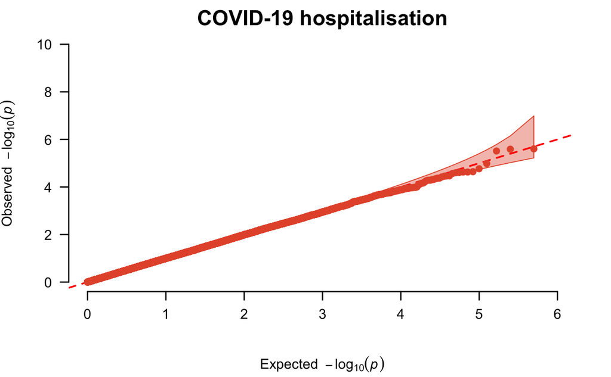

```r
CMplot(Pmap, plot.type = "q",
       col = uithof_color[3], cex.lab = 1,25,
       ylim = 10,
       file.output = FALSE,
       main = "COVID-19 hospitalisation",
       verbose = TRUE)
```

```
 Q_Q Plotting all_inv_var_meta_p.
```

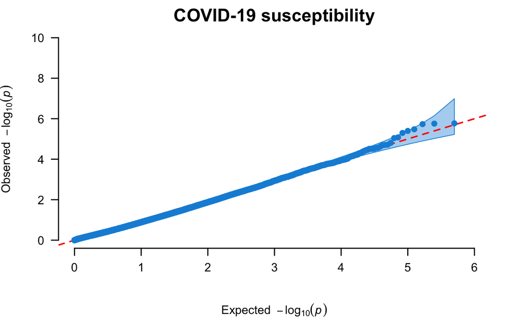

```r
CMplot(Pmap5, plot.type = "q",
       col = uithof_color[16], cex.lab = 1,25,
       ylim = 10,
       file.output = FALSE,
       main = "COVID-19 susceptibility",
       verbose = TRUE)
```

```
 Q_Q Plotting all_inv_var_meta_p.
```

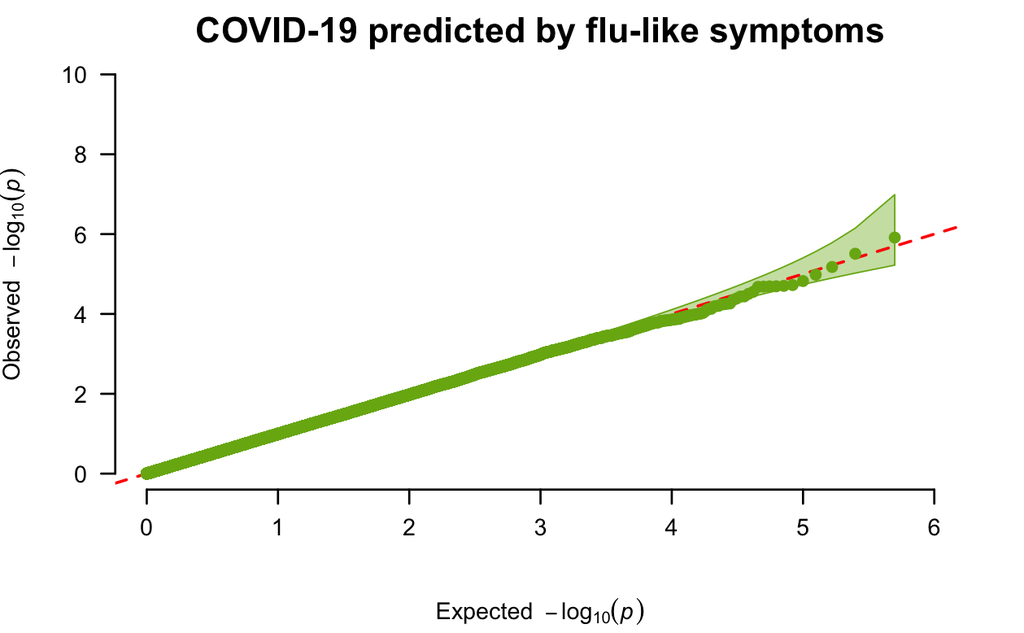

```r
CMplot(Pmap7, plot.type = "q",
       col = uithof_color[23], cex.lab = 1,25,
       ylim = 10,
       file.output = FALSE,
       main = "COVID-19 predicted by flu-like symptoms",
       verbose = TRUE)
```

## Manhattan plot

The Manhattan visualizes all the results.

```
 Rectangular_Manhattan Plotting all_inv_var_meta_p.
```

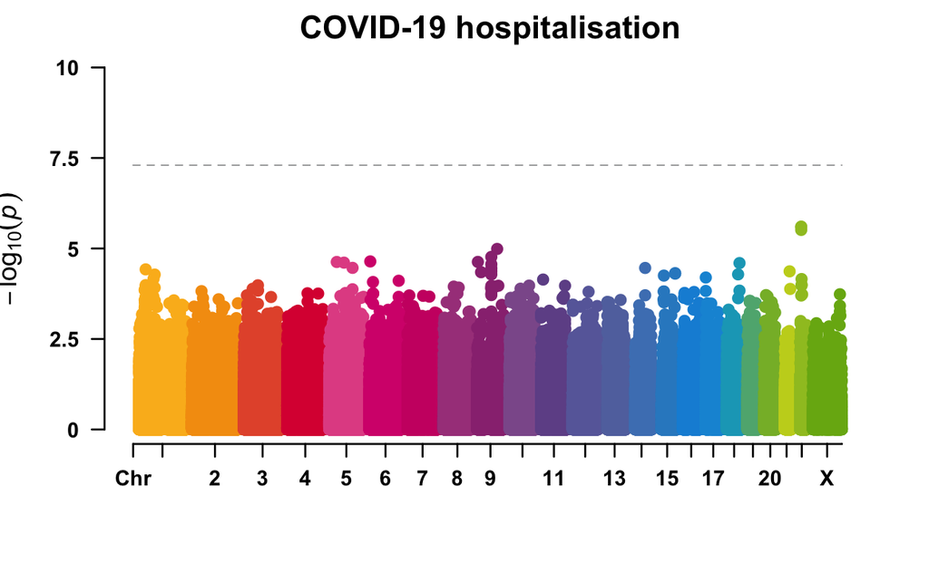

```r
CMplot(Pmap, plot.type = "m",
       col = uithof_color, cex.lab = 1.25,
       # col = c(uithof_color[3], uithof_color[26]), cex.lab = 1.25,
       file.output = FALSE,
       main = "COVID-19 hospitalisation",
       ylim = 10,
       threshold = 5e-8, threshold.col = uithof_color[26], threshold.lty = 2, threshold.lwd = 1,
       amplify = TRUE,
       chr.labels = c(1:22,"X"),
       verbose = TRUE)
```

```
 Rectangular_Manhattan Plotting all_inv_var_meta_p.
```

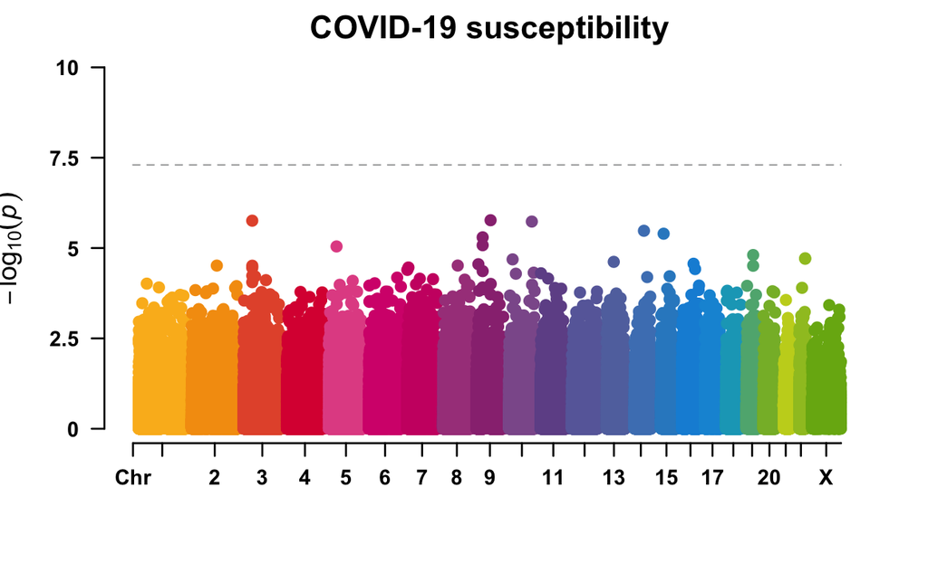

```r
CMplot(Pmap5, plot.type = "m",
       col = uithof_color, cex.lab = 1.25,
       # col = c(uithof_color[16], uithof_color[26]), cex.lab = 1.25,
       file.output = FALSE,
       main = "COVID-19 susceptibility",
       ylim = 10,
       threshold = 5e-8, threshold.col = uithof_color[26], threshold.lty = 2, threshold.lwd = 1,
       amplify = TRUE,
       chr.labels = c(1:22,"X"),
       verbose = TRUE)
```

```
 Rectangular_Manhattan Plotting all_inv_var_meta_p.
```

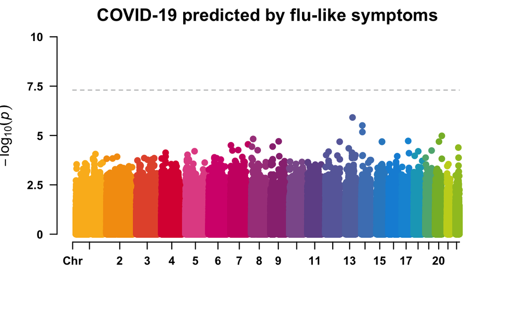

```r
CMplot(Pmap7, plot.type = "m",
       col = uithof_color, cex.lab = 1.25,
       # col = c(uithof_color[23], uithof_color[26]), cex.lab = 1.25,
       file.output = FALSE,
       main = "COVID-19 predicted by flu-like symptoms",
       ylim = 10,
       threshold = 5e-8, threshold.col = uithof_color[26], threshold.lty = 2, threshold.lwd = 1,
       amplify = TRUE,
       chr.labels = c(1:22), #,"X", "Y"),
       verbose = TRUE)
```

## Allele frequencies

We will plot the distribution of the allele frequencies.

```r
p1 <- ggpubr::gghistogram(prelim.gwas.raw,
                    x = "meanAF", y = "..count..",
                    title = "COVID-19 hospitalisation",
                    xlab = "",
                    ylab = "",
                    color = uithof_color[3],
                    fill = uithof_color[3],
                    add = "mean", add.params = list(color = uithof_color[26], linetype = 2, size = 1.25)) #+
```

```
Using `bins = 30` by default. Pick better value with the argument `bins`.geom_vline(): Ignoring `mapping` because `xintercept` was provided.geom_vline(): Ignoring `data` because `xintercept` was provided.
```

```r
  # annotate("text", label = "mean AF", x = 0.30, y = 5e5, colour = uithof_color[26]) #+
  # geom_vline(xintercept = 0.01, colour = uithof_color[3], lty = 1) + #annotate("text", label = "AF = 1%", x = 0.1, y = 5e5, colour = uithof_color[3]) +
  # geom_vline(xintercept = 0.02, colour = uithof_color[13], lty = 1) + #annotate("text", label = "AF = 2%", x = 0.1, y = 4.5e5, colour = uithof_color[13]) +
  # geom_vline(xintercept = 0.03, colour = uithof_color[16], lty = 1) #+ annotate("text", label = "AF = 3%", x = 0.1, y = 4e5, colour = uithof_color[16])

p2 <- ggpubr::gghistogram(prelim.gwas.raw5,
                    x = "meanAF", y = "..count..",
                    title = "COVID-19 susceptibility",
                    xlab = "",
                    ylab = "n variants",
                    color = uithof_color[16],
                    fill = uithof_color[16],
                    add = "mean", add.params = list(color = uithof_color[26], linetype = 2, size = 1.25)) #+
```

```
Using `bins = 30` by default. Pick better value with the argument `bins`.geom_vline(): Ignoring `mapping` because `xintercept` was provided.geom_vline(): Ignoring `data` because `xintercept` was provided.
```

```r
  # annotate("text", label = "mean AF", x = 0.30, y = 5e5, colour = uithof_color[26])

p3 <- ggpubr::gghistogram(prelim.gwas.raw7,
                    x = "meanAF", y = "..count..",
                    title = "COVID-19 predicted by flu-like symptoms",
                    xlab = "allele frequency\n(mean across studies)",
                    ylab = "",
                    color = uithof_color[23],
                    fill = uithof_color[23],
                    add = "mean", add.params = list(color = uithof_color[26], linetype = 2, size = 1.25)) #+
```

```
Using `bins = 30` by default. Pick better value with the argument `bins`.geom_vline(): Ignoring `mapping` because `xintercept` was provided.geom_vline(): Ignoring `data` because `xintercept` was provided.
```

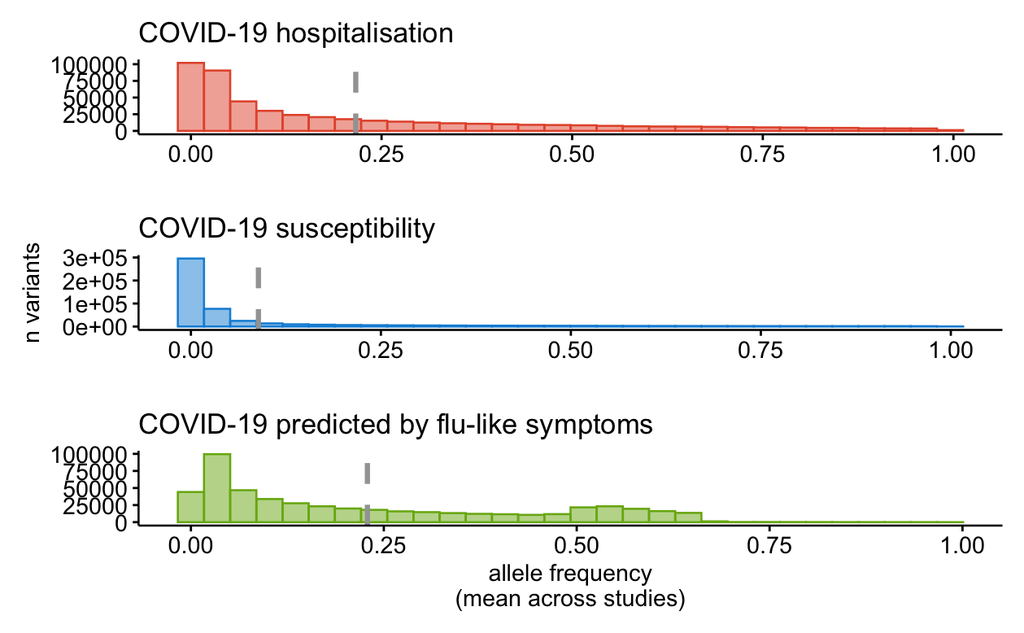

```r
  # annotate("text", label = "mean AF", x = 0.30, y = 5e5, colour = uithof_color[26])


require(patchwork)

p1 / p2 / p3
```

```r
rm(p1, p2, p3)
```

# Filtering data

Given that sample sizes (of the cases) remain small, we will apply a filter at mean AF = 0.005.

```r
prelim.gwas.raw.qc <- prelim.gwas.raw %>%
  filter(meanAF > AF_THRESHOLD)

prelim.gwas.raw5.qc <- prelim.gwas.raw5 %>%
  filter(meanAF > AF_THRESHOLD)

prelim.gwas.raw7.qc <- prelim.gwas.raw7 %>%
  filter(meanAF > AF_THRESHOLD)

# rm(prelim.gwas.raw, prelim.gwas.raw5, prelim.gwas.raw7)
```

## QQ-plot after filter

```r
PmapQC <- prelim.gwas.raw.qc %>%
  select(., SNP, `#CHR`, POS, all_inv_var_meta_p)

PmapQC5 <- prelim.gwas.raw5.qc %>%
  select(., SNP, `#CHR`, POS, all_inv_var_meta_p)

PmapQC7 <- prelim.gwas.raw7.qc %>%
  select(., SNP, `#CHR`, POS, all_inv_var_meta_p)
```

```
 Q_Q Plotting all_inv_var_meta_p.
```

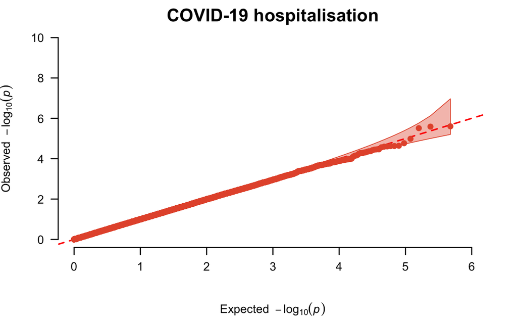

```r
CMplot(PmapQC, plot.type = "q",
       col = uithof_color[3], cex.lab = 1,25,
       ylim = 10,
       file.output = FALSE,
       main = "COVID-19 hospitalisation",
       verbose = TRUE)
```

```
 Q_Q Plotting all_inv_var_meta_p.
```

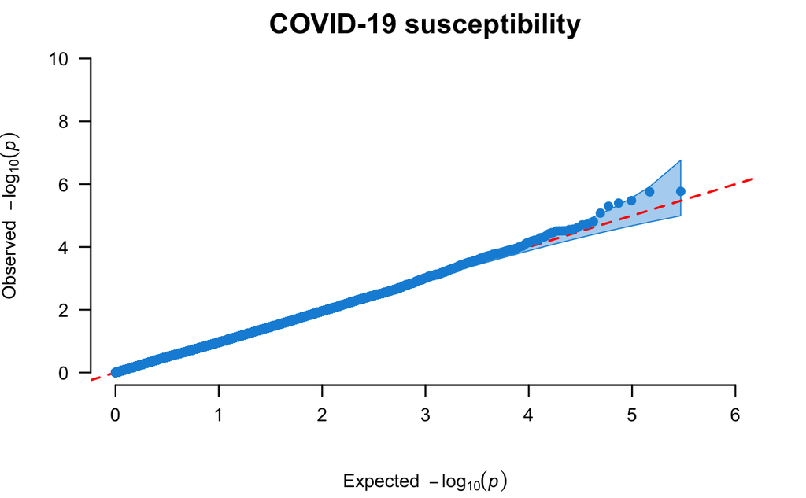

```r
CMplot(PmapQC5, plot.type = "q",
       col = uithof_color[16], cex.lab = 1,25,
       ylim = 10,
       file.output = FALSE,
       main = "COVID-19 susceptibility",
       verbose = TRUE)
```

```
 Q_Q Plotting all_inv_var_meta_p.
```

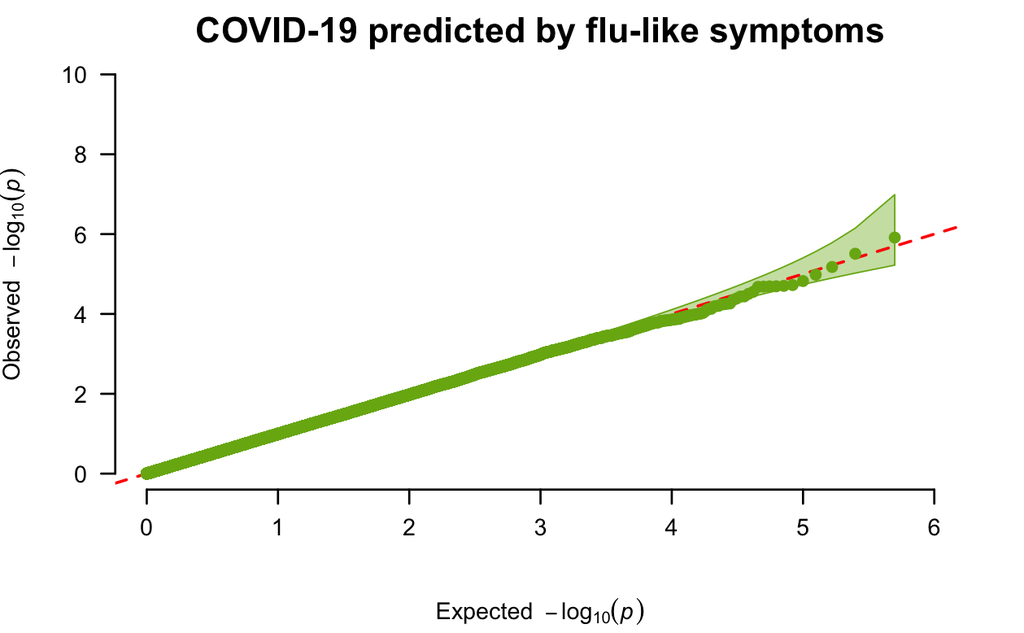

```r
CMplot(PmapQC7, plot.type = "q",
       col = uithof_color[23], cex.lab = 1,25,
       ylim = 10,
       file.output = FALSE,
       main = "COVID-19 predicted by flu-like symptoms",
       verbose = TRUE)
```

## Manhattan plot after filter

```
 Rectangular_Manhattan Plotting all_inv_var_meta_p.
```

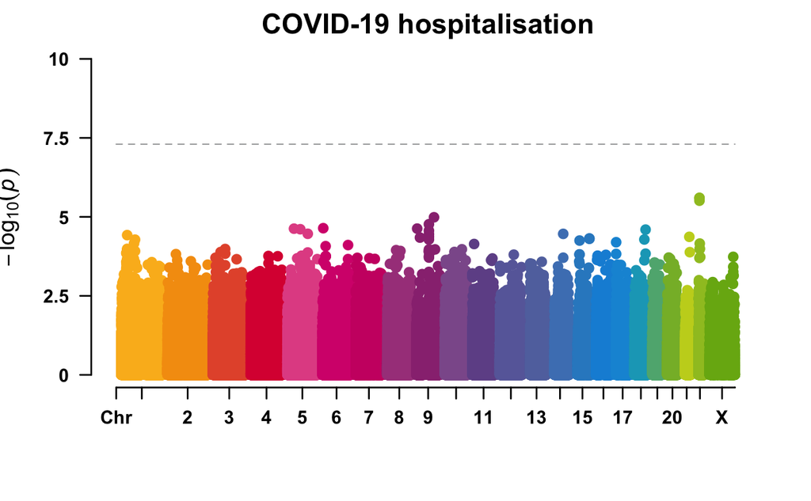

```r
CMplot(PmapQC, plot.type = "m",
       col = uithof_color, cex.lab = 1.25,
       # col = c(uithof_color[3], uithof_color[26]), cex.lab = 1.25,
       file.output = FALSE,
       main = "COVID-19 hospitalisation",
       ylim = 10,
       threshold = 5e-8, threshold.col = uithof_color[26], threshold.lty = 2, threshold.lwd = 1,
       amplify = TRUE,
       chr.labels = c(1:22,"X"),
       verbose = TRUE)
```

```
 Rectangular_Manhattan Plotting all_inv_var_meta_p.
```

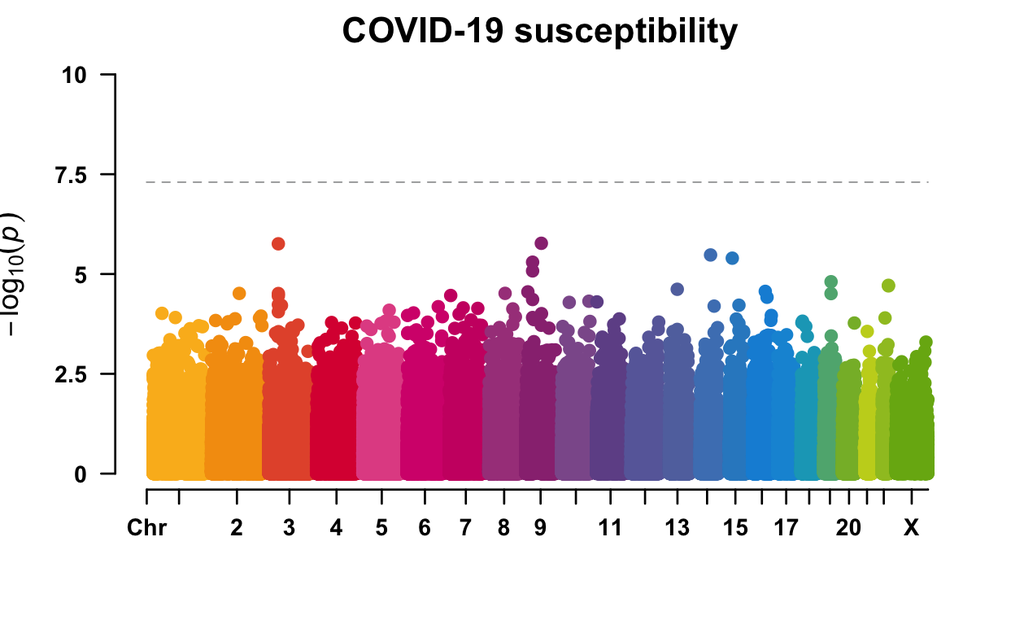

```r
CMplot(PmapQC5, plot.type = "m",
       col = uithof_color, cex.lab = 1.25,
       # col = c(uithof_color[16], uithof_color[26]), cex.lab = 1.25,
       file.output = FALSE,
       main = "COVID-19 susceptibility",
       ylim = 10,
       threshold = 5e-8, threshold.col = uithof_color[26], threshold.lty = 2, threshold.lwd = 1,
       amplify = TRUE,
       chr.labels = c(1:22,"X"),
       verbose = TRUE)
```

```
 Rectangular_Manhattan Plotting all_inv_var_meta_p.
```

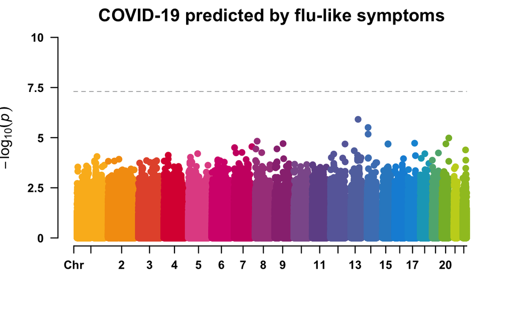

```r
CMplot(PmapQC7, plot.type = "m",
       col = uithof_color, cex.lab = 1.25,
       # col = c(uithof_color[23], uithof_color[26]), cex.lab = 1.25,
       file.output = FALSE,
       main = "COVID-19 predicted by flu-like symptoms",
       ylim = 10,
       threshold = 5e-8, threshold.col = uithof_color[26], threshold.lty = 2, threshold.lwd = 1,
       amplify = TRUE,
       chr.labels = c(1:22), #,"X", "Y"),
       verbose = TRUE)
```

# Version & change log

```
Version:      v1.0.1
Last update:  2020-05-16
Written by:   Sander W. van der Laan (s.w.vanderlaan-2[at]umcutrecht.nl).
Description:  Script to review the (preliminary) meta-GWAS results from the COVID19-HGI.
Minimum requirements: R version 3.4.3 (2017-06-30) -- 'Single Candle', Mac OS X El Capitan


Changes log
* v1.0.1 Second round meta-analysis, preliminary results.
* v1.0.0 Initial version. First round meta-analysis, preliminary results.
```

# Saving environment

Actually: we don’t want to save the data, this makes the `.RData`-file too large…

```r
rm(prelim.gwas.raw, prelim.gwas.raw5, prelim.gwas.raw7,
   Pmap, Pmap5, Pmap7,
   PmapQC, PmapQC5, PmapQC7)
save.image(paste0(PROJECT_loc, "/",Today,".",PROJECTNAME,".",SUBPROJECTNAME,".RData"))
```

| <sup>© 1979-2020 Sander W. van der Laan \| s.w.vanderlaan-2[at]umcutrecht.nl \| swvanderlaan.github.io.</sup> |
| --- |

*Footnotes*

[^1]: [The COVID-19 Host Genetics Initiative *The COVID-19 Host Genetics Initiative, a global initiative to elucidate the role of host genetic factors in susceptibility and severity of the SARS-CoV-2 virus pandemic* **EJHG 2020**.](https://www.nature.com/articles/s41431-020-0636-6).
[^2]: McCarthy, M. I. *et al.* Genome-wide association studies for complex traits: consensus, uncertainty and challenges. **Nat. Rev. Genet.** 9, 356–369 (2008).